# Prediction Assignment

Damian Brunold

The dataset contains data collected from activity trackers while the test persons were performing certain exercise tasks. They were told to perform the exercises in five different ways. Our task ist to build a predictive model for predicting which of the five ways of performing the exercises was used.

```r
library(caret)
data <- read.csv("pml-training.csv")
dim(data)
```

```
## [1] 19622   160
```

The outcome is stored in the classe variable.

```r
table(data$classe)
```

```
##
##    A    B    C    D    E
## 5580 3797 3422 3216 3607
```

One observation looks like this:

```r
head(data, n = 1)
```

[output not shown]

[output cut: 25 more lines]

[output not shown]

As most features are empty for most users, we restrict ourselves to the roll, pitch and yaw features for each of forearm, dumbbell, arm and belt.

```r
features <- names(data)[grepl("^(roll|pitch|yaw)_(forearm|dumbbell|arm|belt)$", names(data))]
```

We split the data into training and testing with 70% of observations used for training and 30% for validation.

```r
set.seed(1234)
inTrain <- sample(nrow(data), floor(nrow(data) * 0.7))
training <- data[inTrain,c("classe", features)]
testing <- data[-inTrain,c("classe", features)]
```

As we have a classification task, I try three different classification models and check the performance of each one using the testing dataset. I chose random forests, linear discriminant analysis and boosted logistic regression.

```r
model1 <- train(classe ~ ., training, method = "rf")
model2 <- train(classe ~ ., training, method = "lda")
model3 <- train(classe ~ ., training, method = "LogitBoost")
```

Using these models, lets predict the values for the testing set.

```r
pred1 <- predict(model1, newdata = testing)
pred2 <- predict(model2, newdata = testing)
pred3 <- predict(model3, newdata = testing)
```

Performance of random forest model:

```r
confusionMatrix(pred1, testing$classe)
```

```
## Confusion Matrix and Statistics
##
##           Reference
## Prediction    A    B    C    D    E
##          A 1712   16    0    1    0
##          B    2 1039    6    1    2
##          C    1   18 1000    5    5
##          D    0    3   16  984    4
##          E    1    0    1    0 1070
##
## Overall Statistics
##
##                Accuracy : 0.9861
##                  95% CI : (0.9827, 0.9889)
##     No Information Rate : 0.2915
##     P-Value [Acc > NIR] : < 2.2e-16
##
##                   Kappa : 0.9824
##  Mcnemar's Test P-Value : 0.0001102
##
## Statistics by Class:
##
##                      Class: A Class: B Class: C Class: D Class: E
## Sensitivity            0.9977   0.9656   0.9775   0.9929   0.9898
## Specificity            0.9959   0.9977   0.9940   0.9953   0.9996
## Pos Pred Value         0.9902   0.9895   0.9718   0.9772   0.9981
## Neg Pred Value         0.9990   0.9924   0.9953   0.9986   0.9977
## Prevalence             0.2915   0.1828   0.1738   0.1683   0.1836
## Detection Rate         0.2908   0.1765   0.1699   0.1671   0.1818
## Detection Prevalence   0.2937   0.1784   0.1748   0.1711   0.1821
## Balanced Accuracy      0.9968   0.9817   0.9858   0.9941   0.9947
```

The random forest model has impressive accuracy. Overall it is 0.986 and the 95% CI is (0.9827, 0.9889). Three of the five classes even reach accuracy above 0.99.

Performance of linear discriminant analysis model:

```r
confusionMatrix(pred2, testing$classe)
```

```
## Confusion Matrix and Statistics
##
##           Reference
## Prediction    A    B    C    D    E
##          A 1170  307  281  133  201
##          B  180  290   80  166  257
##          C  100  126  433  105  226
##          D  150  205  100  463  177
##          E  116  148  129  124  220
##
## Overall Statistics
##
##                Accuracy : 0.4376
##                  95% CI : (0.4249, 0.4504)
##     No Information Rate : 0.2915
##     P-Value [Acc > NIR] : < 2.2e-16
##
##                   Kappa : 0.2814
##  Mcnemar's Test P-Value : < 2.2e-16
##
## Statistics by Class:
##
##                      Class: A Class: B Class: C Class: D Class: E
## Sensitivity            0.6818  0.26952  0.42326  0.46720  0.20352
## Specificity            0.7789  0.85803  0.88549  0.87092  0.89243
## Pos Pred Value         0.5593  0.29805  0.43737  0.42283  0.29851
## Neg Pred Value         0.8561  0.84005  0.87952  0.88982  0.83282
## Prevalence             0.2915  0.18278  0.17377  0.16834  0.18362
## Detection Rate         0.1987  0.04926  0.07355  0.07865  0.03737
## Detection Prevalence   0.3554  0.16528  0.16817  0.18600  0.12519
## Balanced Accuracy      0.7304  0.56378  0.65438  0.66906  0.54797
```

Performance of boosted logistical regression model:

```r
confusionMatrix(pred3, testing$classe)
```

```
## Confusion Matrix and Statistics
##
##           Reference
## Prediction    A    B    C    D    E
##          A 1419   60   43   13   15
##          B   41  641  116   28   38
##          C   19   38  493   37   14
##          D   29   15   53  653   37
##          E   19    7    2   20  812
##
## Overall Statistics
##
##                Accuracy : 0.8619
##                  95% CI : (0.8516, 0.8716)
##     No Information Rate : 0.3275
##     P-Value [Acc > NIR] : < 2.2e-16
##
##                   Kappa : 0.8224
##  Mcnemar's Test P-Value : < 2.2e-16
##
## Statistics by Class:
##
##                      Class: A Class: B Class: C Class: D Class: E
## Sensitivity            0.9293   0.8423   0.6973   0.8695   0.8865
## Specificity            0.9582   0.9428   0.9727   0.9657   0.9872
## Pos Pred Value         0.9155   0.7419   0.8203   0.8297   0.9442
## Neg Pred Value         0.9653   0.9684   0.9473   0.9747   0.9726
## Prevalence             0.3275   0.1632   0.1517   0.1611   0.1965
## Detection Rate         0.3044   0.1375   0.1057   0.1401   0.1742
## Detection Prevalence   0.3325   0.1853   0.1289   0.1688   0.1845
## Balanced Accuracy      0.9437   0.8926   0.8350   0.9176   0.9368
```

We choose the best model based on random forests with accuracy of 0.98 on the test data. As the model was trained without using the test data, I expect the general out of sample error to be 2%.

```r
best.model <- model1
```

Lets have a look at the variable importance:

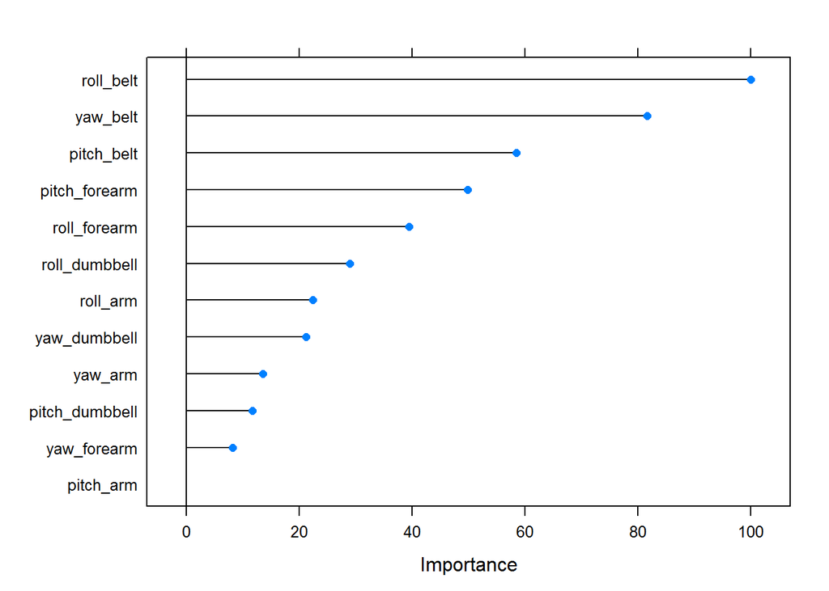

```r
plot(varImp(model1))
```

Except for pitch_arm, all features have a reasonably high importance.

Now we can load and predict the actual test cases:

```r
pred.data <- read.csv("pml-testing.csv")
pred.data <- pred.data[,features]
prediction <- predict(best.model, newdata = pred.data)
prediction
```

```
##  [1] B A B A A E D B A A B C B A E E A B B B
## Levels: A B C D E
```